# Documentos Interactivos

## Inputs: actionButton (*Ejemplo 2*)

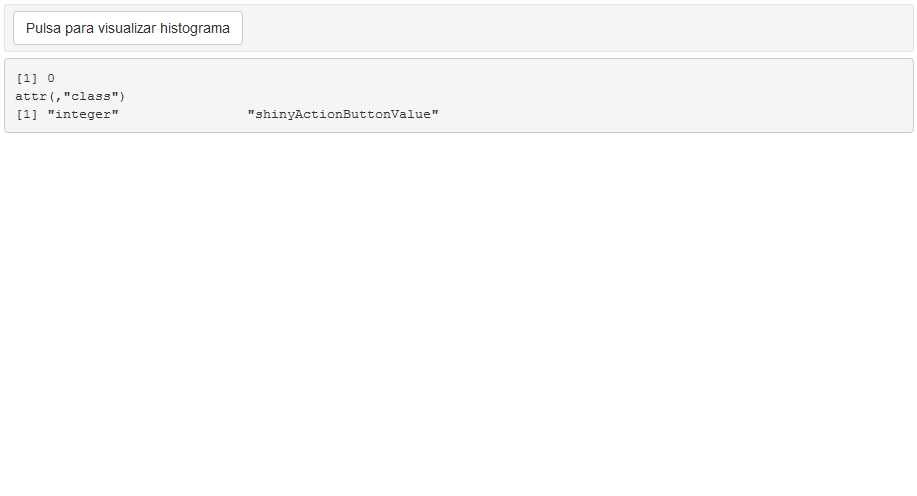

## Inputs: actionButton (*Ejemplo 3*)

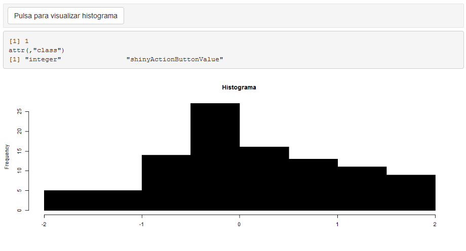

## Inputs > actionButton (Ejemplo 4)

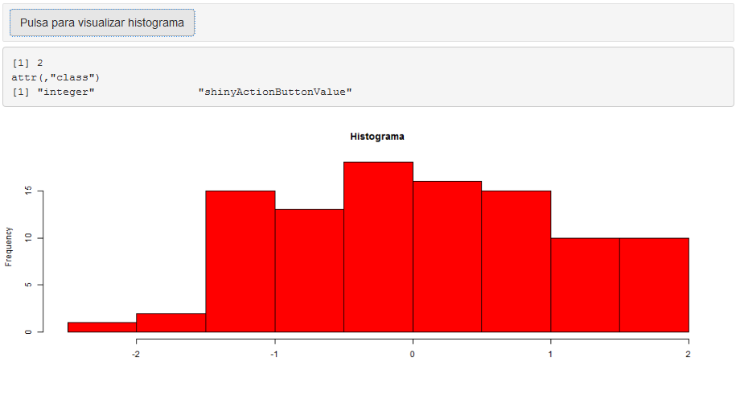

## Inputs: fileInput (*Sintaxis*)

```r
fileInput(inputId, label, multiple = FALSE, accept = NULL, width = NULL)
```

**Arguments**

**`multiple`**: `Whether the user should be allowed to select and upload multiple files at once. Does not work on older browsers, including Internet Explorer 9 and earlier.`

Mediante esta opción indicamos si permitimos cargar más de un fichero o no.

(En el parámetro *accept* se puede indicar el tipo de fichero que espera, aunque el explorador de RStudio, al menos, ignora este parámetro y permite seleccionar cualquier tipo de fichero)

## Inputs: filetInput (*Sintaxis 2*)

**Details**

El programa avisa cuando la carga del fichero, o ficheros, se ha completado. La variable asociada a este *input* es un *dataframe* en el que podemos encontrar una fila por cada fichero cargado y varias columnas cuyos nombres y contenidos son los siguientes:

**`name`**: Nombre del fichero

**`size`**: Tamaño del fichero (bytes)

**`type`**: El tipo de fichero (que devuelve el explorador) o vacío si no es conocido.

**`datapath`**: La ruta de acceso a un archivo temporal que contiene los datos cargados (este archivo temporal desaparecerá si el usuario realiza otra operación de carga).

## Inputs: fileInput (*Ejemplo 1*)

```r
inputPanel(
fileInput("fichero", label ="Selecciona un fichero csv",multiple = FALSE)
)
renderPrint(
    input$fichero
)
renderPrint(
  names(input$fichero)
)
renderPrint({
  if(is.null(input$fichero)) return(NULL)
  head(read.csv(input$fichero$datapath,sep=";"))
})
```

## Inputs: fileInput (*Ejemplo 2*)

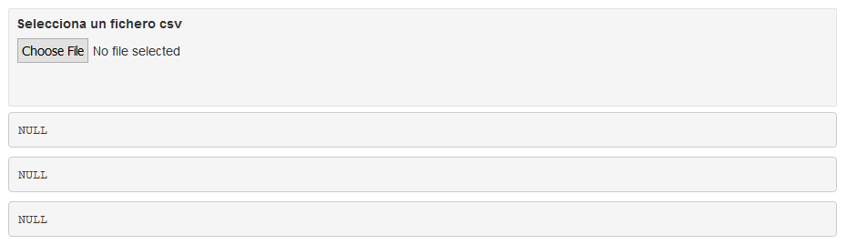

## Inputs: fileInput (*Ejemplo 3*)

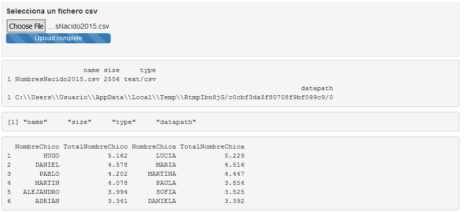

## Inputs: sliderInput

- Permite seleccionar un valor en un rango propuesto o dos valores que definen un rango (también en un rango inicial propuesto).
- Toma un valor (el seleccionado) o un vector con dos valores en el caso de poder seleccionar dos valores.
- El hecho de poder seleccionar uno o dos valores depende de cómo se defina el control.

## Inputs: sliderInput (*Sintaxis 1*)

```r
sliderInput(inputId, label, min, max, value, step = NULL, round = FALSE,
  format = NULL, locale = NULL, ticks = TRUE, animate = FALSE,
  width = NULL, sep = ",", pre = NULL, post = NULL, timeFormat = NULL,
  timezone = NULL, dragRange = TRUE)
```

**Arguments**

**`min`**: `The minimum value (inclusive) that can be selected.`

**`max`**: `The maximum value (inclusive) that can be selected.`

Valores mínimo y máximo del selector.

## Inputs: sliderInput (*Sintaxis 2*)

```r
sliderInput(inputId, label, min, max, value, step = NULL, round = FALSE,
  format = NULL, locale = NULL, ticks = TRUE, animate = FALSE,
  width = NULL, sep = ",", pre = NULL, post = NULL, timeFormat = NULL,
  timezone = NULL, dragRange = TRUE)
```

**`value`**: `The initial value of the slider. A numeric vector of length one will create a regular slider; a numeric vector of length two will create a double-ended range slider. A warning will be issued if the value doesn't fit between min and max.`

Este valor inicial determina el tipo de selector. Si se da un único valor (que debe estar dentro del rango establecido) el selector permitirá elegir un solo valor, si se proporciona un vector con dos valores (también dentro del rango establecido), el selector permitirá elegir un par de valores que definirán el rango seleccionado.

## Inputs: sliderInput (*Sintaxis 3*)

```r
sliderInput(inputId, label, min, max, value, step = NULL, round = FALSE,
  format = NULL, locale = NULL, ticks = TRUE, animate = FALSE,
  width = NULL, sep = ",", pre = NULL, post = NULL, timeFormat = NULL,
  timezone = NULL, dragRange = TRUE)
```

**Arguments**

**`step`**: `Specifies the interval between each selectable value on the slider (if NULL, a heuristic is used to determine the step size). If the values are dates, step is in days; if the values are times (POSIXt), step is in seconds.`

En este parámetro indicaremos el *paso* entre dos valores consecutivos de la barra selectora (saltos de uno en uno, dos en dos,…). Determinará qué valores se podrán elegir y aquellos que no podrán ser elegidos.

## Inputs: sliderInput (*Ejemplo 1*)

```r
inputPanel(
  sliderInput("slider1", label = h3("Selecciono rango mínimo y máximo"),
              min = 0, max = 100,
              value = c(40,60))
)
renderPrint({
  input$slider1
})


inputPanel(
  sliderInput("slider2", label = h3("Selecciono rango máximo"),
              min = 0, max = 100,
              value = 50)
)

renderPrint({
  input$slider2
})
```

## Inputs: sliderInput (*Ejemplo 2*)

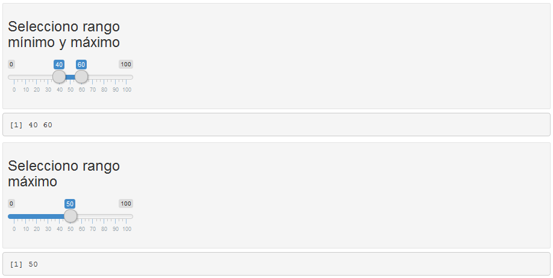

## Inputs: sliderInput (*Ejemplo 3*)

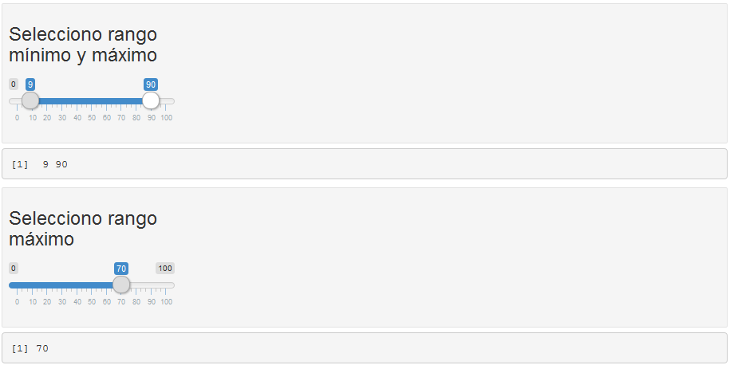

## Widgets: Outputs

## Widgets: Outputs

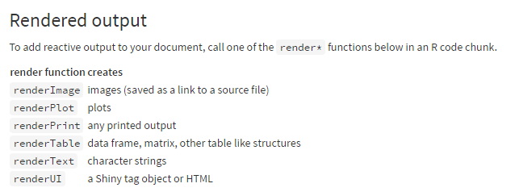

De la misma forma que disponemos de unos objetos que permitirán al usuario seleccionar algunas opciones que determinarán la forma o contenido del documento interactivo (`inputs`), disponemos de diferentes opciones para presentar resultados de texto, numéricos o gráficos (`outputs`).

## Outputs: renderPrint (*Sintaxis*)

Útil para mostrar cualquier salida de resultados (*summary* de un banco de datos o resultado de un análisis estadístico)

```r
renderPrint(expr, env = parent.frame(), quoted = FALSE, func = NULL,
  width = getOption("width"))
```

**Arguments**

**`expr`**: `An expression that may print output and/or return a printable R object.`

Esta salida, como hemos visto durante la introducción de los tipos de *input* sirve para mostrar cualquier resultado numérico, de texto que pueda ser impreso.

## Outputs: renderPrint (*Ejemplo 1*)

```r
data("DNase")

inputPanel(
  selectInput(inputId = "seleccionaFun", label="Selecciona función",
              choices = c("Covarianza"=1,"Correlación"=2),selected = 1)
)

renderPrint({
  if(input$seleccionaFun==1){cov(DNase[,2:3])}
  else{cor(DNase[,2:3])}
})
```

## Outputs: renderPrint (*Ejemplo 2*)

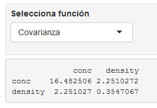

## Outputs: renderText (*Sintaxis*)

```r
renderText(expr, env = parent.frame(), quoted = FALSE, func = NULL)
```

**Arguments**

**`expr`**: `An expression that returns an R object that can be used as an argument to cat.`

En este tipo de salida podemos mostrar cualquier texto que pueda ser mostrado en R mediante la función `cat`. Puede incluir varias líneas incorporando el caracter `\n`.

## Outputs: renderText (*Ejemplo 1*)

```r
data("DNase")

renderText({
  names(input) #imprimimos contenido objeto input
})
```